# HW11 - Logistic Regression

Madhu Peduri

July 14, 2021

### Problem 1(a)

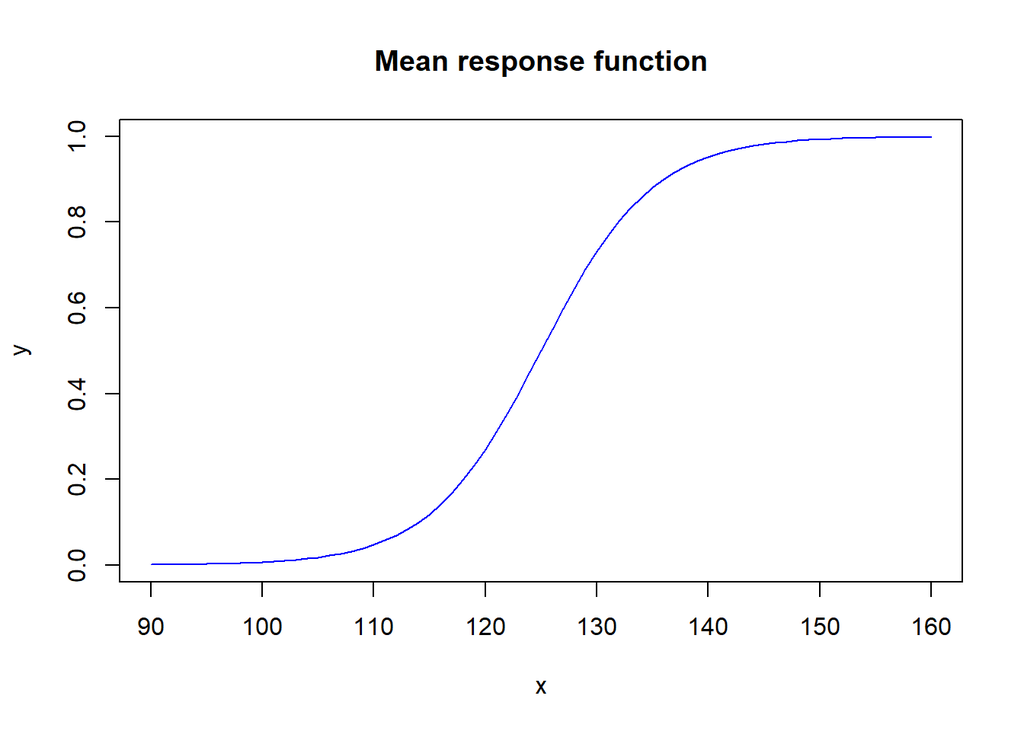

```r
# Independent variable x
x <- seq(90, 160, 1)

# coefficients of linear predictor
intercept <- -25
coef1 <- 0.2

# link function, mean response function of a logistic
# regression model
mrf <- function(var) {
    val <- exp(-25 + 0.2 * var)/(1 + exp(-25 + 0.2 * var))
    val
}

# Response variable
y <- sapply(x, mrf)

# plot the model
plot(x, y, type = "l", col = "blue", main = "Mean response function")
```

```r
lm1 <- glm(y ~ x, family = binomial)
```

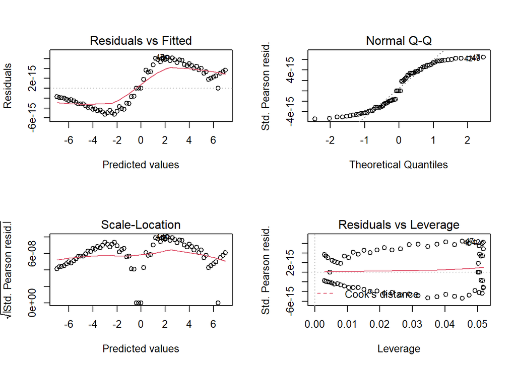

```r
par(mfrow = c(2, 2))
plot(lm1)
```

### Problem 1(b)

```r
# logit(x) = log(x/(1-x))
x_val <- (logit(0.5) - intercept)/coef1
sprintf("Value of x when probability Pr(Y=0.5) is: %.2f", x_val)
```

```
## [1] "Value of x when probability Pr(Y=0.5) is: 125.00"
```

```r
# Compare with glm model
dose.p(lm1, p = 0.5)
```

```
##          Dose   SE
## p = 0.5:  125 2.24
```

### Problem 1(c)

```r
# Odds when x=150
o1 <- mrf(150)/(1 - mrf(150))
sprintf("Odds when x=150: %.3f", o1)
```

```
## [1] "Odds when x=150: 148.413"
```

```r
# Odds when x=151
o2 <- mrf(151)/(1 - mrf(151))
sprintf("Odds when x=151: %.3f", o2)
```

```
## [1] "Odds when x=151: 181.272"
```

```r
# Ratio of odds
r <- o2/o1
sprintf("Ratio of odds 151 to 150: %.3f", r)
```

```
## [1] "Ratio of odds 151 to 150: 1.221"
```

```r
sprintf("exp of coefficient: %.3f", exp(coef1))
```

```
## [1] "exp of coefficient: 1.221"
```

#### Observation

- The ratio of odds for two values x=151 to x=150, a unit measure in x, is equal to the exp(coefficient) of the linear predictor.

### Problem 2(a)

```r
# read the data
q2 <- read.table("Q2.txt", quote = "\"", comment.char = "")
colnames(q2) <- c("y", "income", "age")

# print summary
str(q2)
```

```
## 'data.frame':    33 obs. of  3 variables:
##  $ y     : num  0 0 1 0 0 1 1 1 0 1 ...
##  $ income: num  32 45 60 53 25 68 82 38 67 92 ...
##  $ age   : num  3 2 2 1 4 1 2 5 2 2 ...
```

```r
mod2 <- glm(y ~ income + age, family = binomial(link = "logit"),
    data = q2)
summary(mod2)
```

```
##
## Call:
## glm(formula = y ~ income + age, family = binomial(link = "logit"),
##     data = q2)
##
## Deviance Residuals:
##    Min      1Q  Median      3Q     Max
## -1.619  -0.895  -0.588   0.965   2.085
##
## Coefficients:
##             Estimate Std. Error z value Pr(>|z|)
## (Intercept)  -4.7393     2.1019   -2.25    0.024 *
## income        0.0677     0.0281    2.41    0.016 *
## age           0.5986     0.3901    1.53    0.125
## ---
## Signif. codes:  0 '***' 0.001 '**' 0.01 '*' 0.05 '.' 0.1 ' ' 1
##
## (Dispersion parameter for binomial family taken to be 1)
##
##     Null deviance: 44.987  on 32  degrees of freedom
## Residual deviance: 36.690  on 30  degrees of freedom
## AIC: 42.69
##
## Number of Fisher Scoring iterations: 4
```

```r
str(summary(mod2))
```

[output not shown]

```r
# Coefficients
mod2$coefficients
```

```
## (Intercept)      income         age
##     -4.7393      0.0677      0.5986
```

```r
sprintf("Beta0(Intercept):%.4f", mod2$coefficients[1])
```

```
## [1] "Beta0(Intercept):-4.7393"
```

```r
sprintf("Beta1(Coefficient1):%.4f", mod2$coefficients[2])
```

```
## [1] "Beta1(Coefficient1):0.0677"
```

```r
sprintf("Beta2(Coefficient2):%.4f", mod2$coefficients[3])
```

```
## [1] "Beta2(Coefficient2):0.5986"
```

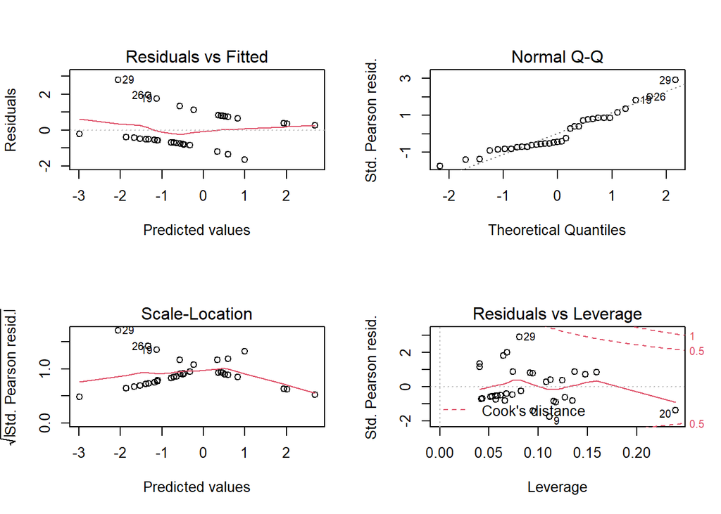

```r
# plot the model
par(mfrow = c(2, 2))
plot(mod2)
```

### Problem 2(b)

```r
# Compute linear predictor
eq <- function(i, a) {
    mod2$coefficients[1] + mod2$coefficients[2] * i + mod2$coefficients[3] *
        a
}

# compute probabilities keeping age constant
p1 <- ilogit(eq(32, 3))
p2 <- ilogit(eq(33, 3))

# Compute the odds
o1 <- p1/(1 - p1)
o2 <- p2/(1 - p2)

# Compare Ratio of odds and exp(intercept)
o2/o1
```

```
## (Intercept)
##        1.07
```

```r
exp(mod2$coefficients[2])
```

```
## income
##   1.07
```

```r
# compute probabilities keeping age constant
p1 <- ilogit(eq(32, 3))
p2 <- ilogit(eq(32, 4))

# Compute the odds
o1 <- p1/(1 - p1)
o2 <- p2/(1 - p2)

# Compare Ratio of odds and exp(intercept)
o2/o1
```

```
## (Intercept)
##        1.82
```

```r
exp(mod2$coefficients[3])
```

```
##  age
## 1.82
```

#### Observation

- exp(beta1): This is the coefficient for income. We can see a unit change in the income predictor, by keeping age as constant) makes the ratio of odds(income) equal to the exp(beta1).
- exp(beta2): This is the coefficient for age We can see a unit change in the age predictor, by keeping income as constant) makes the ratio of odds(age) equal to the exp(beta2).

### Problem 2(c)

```r
# prob for income=50, age=3 using coefficients
ilogit(eq(50, 3))
```

```
## (Intercept)
##       0.609
```

```r
# prob for income=50, age=3 using predict method
predict(mod2, newdata = data.frame(income = 50, age = 3), type = "response")
```

```
##     1
## 0.609
```

```r
pr1 <- predict(mod2, newdata = data.frame(income = 50, age = 3),
    se = T)

ilogit(c(pr1$fit - 1.96 * pr1$se.fit, pr1$fit + 1.96 * pr1$se.fit))
```

```
##     1     1
## 0.365 0.808
```

### Problem 2(d)

```r
# using likelihood approach
confint(mod2)
```

```
##               2.5 % 97.5 %
## (Intercept) -9.4452 -1.049
## income       0.0195  0.132
## age         -0.1222  1.447
```

```r
# 95% CI for using normal approximations
c(0.0677 - 1.96 * 0.0281, 0.0677 + 1.96 * 0.0281)
```

```
## [1] 0.0126 0.1228
```

```r
c(0.5986 - 1.96 * 0.3901, 0.5986 + 1.96 * 0.3901)
```

```
## [1] -0.166  1.363
```

#### Observations

- Income: For every unit increase in this variable, the odds of buying the car increases by approximately 1.07 with 95% certainity that coefficient is with in the values (0.0195 0.132)
- Age: For every unit increase in this variable, the odds of buying the car increases by approximately 1.82 with 95% certainity that coefficient is with in the values (-0.1222 1.447)

### Problem 2(e)

```r
deviance <- mod2$null.deviance - mod2$deviance
sprintf("Deviance of the logistic model: %.3f", deviance)
```

```
## [1] "Deviance of the logistic model: 8.298"
```

```r
anova(mod2, test = "Chisq")
```

|  | Df | Deviance | Resid. Df | Resid. Dev | Pr(>Chi) |
| --- | --- | --- | --- | --- | --- |
| NULL | NA | NA | 32 | 45.0 | NA |
| income | 1 | 5.68 | 31 | 39.3 | 0.0171 |
| age | 1 | 2.61 | 30 | 36.7 | 0.1059 |

## Document Information.

All of the statistical analyses in this document will be performed using R version 4.1.0 (2021-05-18). R packages used will be maintained using the [packrat](http://rstudio.github.io/packrat/) dependency management system.